# ExtraaLearn Project

### **Top Model Performance Comparison**

We are going to visualize the key performance metrics of our best models to get a clearer comparison.

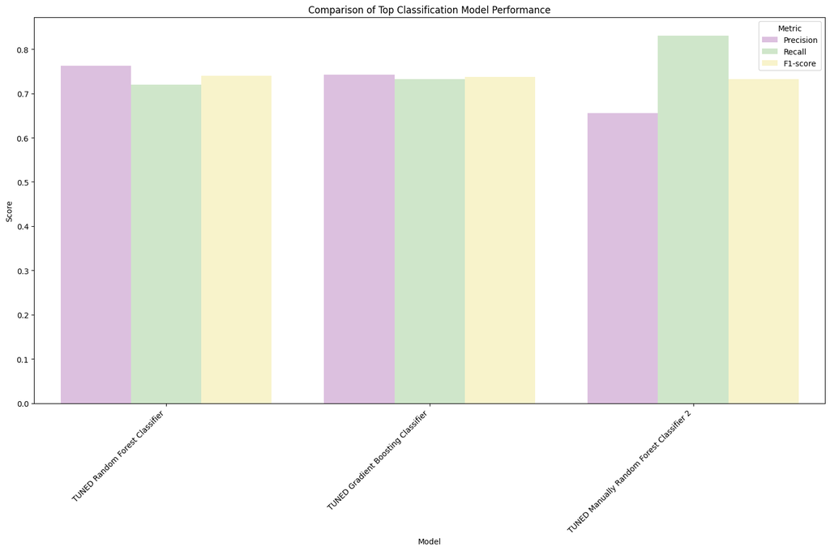

```python
# Select top models for comparison. I am going to plot just 3 models
top_models = models_test_comp_df.T.sort_values(by='F1-score', ascending=False).head(3)

# Metrics to plot just 3 more important for the case
metrics_to_plot = ['Precision', 'Recall', 'F1-score']

plt.figure(figsize=(15, 10))
sns.barplot(data=top_models[metrics_to_plot].reset_index().melt(id_vars='index'),
            x='index', y='value', hue='variable', palette=['#E0BBE4', '#ccebc5', '#FFF9C4'])
plt.title('Comparison of Top Classification Model Performance')
plt.ylabel('Score')
plt.xlabel('Model')
plt.xticks(rotation=45, ha='right')
plt.legend(title='Metric')
plt.tight_layout()
plt.show()
```

**Observations:**

```
Classification Report and Confusion Matrix for Tuned Gradient Boosting Classifier:
              precision    recall  f1-score   support

           0       0.89      0.90      0.89       980
           1       0.74      0.73      0.74       400

    accuracy                           0.85      1380
   macro avg       0.82      0.81      0.82      1380
weighted avg       0.85      0.85      0.85      1380
```

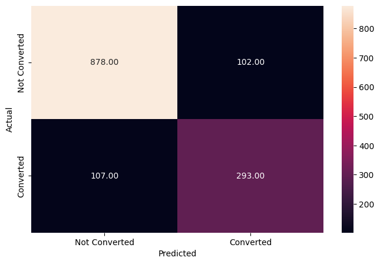

```python
# Function to print the classification report

def metrics_score(actual, predicted):
    print(classification_report(actual, predicted))
    con_matrix = confusion_matrix(actual, predicted)
    plt.figure(figsize = (8, 5))
    sns.heatmap(con_matrix, annot = True,  fmt = '.2f', xticklabels = ['Not Converted', 'Converted'],
                yticklabels = ['Not Converted', 'Converted'])
    plt.ylabel('Actual')
    plt.xlabel('Predicted')
    plt.show()

print('Classification Report and Confusion Matrix for Tuned Gradient Boosting Classifier:')
metrics_score(y_test, gb_tuned_classifier.predict(x_test))
```

***Observations for the Confusion Matrix** The plot shows the actual versus predicted counts:

The model shows good overall performance, with a reasonable balance between precision and recall for the 'Converted' class.

**Insigths**

**Actionable Business Recommendations**

1. Analyse the income in terms of the profile of leads that more convert. Having already identified the main 3 features of the profile, Extralearn can filter the enrolled leads that match the profile out of the whole population of customers to determine if in fact, this group of customers represent at least more than the 50% of the income. This would be a test for the profile determined previously. If the profile support the income in good proportion it means Extralearn can focus on assuring that those type of leads are well taking care during the lead lifetime, by implementing aditional steps or performance indicators per stage of the funnel. If the current income is not really supported by the profile, which can be another situation with much more reasons involved given the time variations, changes in market or changes in offer, it would be good to determine the best combination of features taking the income variable as part of the dataset, the features of clients that in fact make the business profitable.
2. In general, for this case, all of the sources of leads, represent by itself a very few portion of the total of the leads that became paid customers within each category. In order to convert more leads to paid customers, first we need to **increase the quantity and the quality of leads**. I would recommend to the marketing department to diversify even more the sources of leads by:
- Defining or redefining the strategy in terms of the offer, prices and align the marketing objetives to achieve the strategy taking as well in consideration the income analysis from point 1. The programs available in their offer vs. the type of leads that they are going to focus on to maximize their income, for example with current occupation students. In the data we saw the paid customers were mainly people older than 40 years old and around 55 years old, mostly professionals or unemployed. ExtraLearn could start a pilot project on getting younger leads/students since the problem narrative include upskill, not just reskill.
- Promoting their programs in educational fairs organized by local governments where the people go specifically looking for programs online.
- Analyze and implement a good price strategy that allows young or unemployed people to join their programs.
- Getting databases from specific high schools that are aligned to their new iniciative of getting younger leads/ client target to send focus campaigns for those kids that look for online education in the areas where ExtraLearn has an academic offer.
- Partnering with recognized education counselors or educational consulting companies to offer an incentive program that articulates academic guidance and support to clients/professionals and unempoyed leads more than 40 yo mainly, or students of all ages pointing out the ExtraLearn programs available online.
- Sending targeted messages to users, professionals, in Linkedin filtered by specific job titles that match with the ExtraLearn academic offer.
3. Once the leads are in the pipeline, ExtraLearn needs to **improve the capacity to convert, by creating new ways to keep the lead hot**, assuring easy access to information, resolving doubts about the programs offered, providing a fast enrollment process and payment flexibility. All the stages are important to keep the lead hooked until it takes the final decision of enrollment, for example:
- Specific follow up by email and phone, double the efforts, for the leads that spend more than 5 minutes on the website per visit and visit the website more than 3 times which is the average. This is a recommendation made from the combination of some of the previous analysis.
- Tuition calculators that show real costs after financial aid, simulators can be added to the website to give a fast idea of the investment, useful for the people that do not want to talk until they know how much it will cost.
- Offering flexibility and different ways to pay depending on the price of the program.
- Offering free course modules to showcase the value of their programs can be a good option for the difficult leads, the ones that are interested but need a push to take the decision.